# Dallas Housing Market Study

Maxwell Fritz

# Overview

## Data

The majority of the original data will be sourced from data products provided publicly by the DCAD (http://www.dallascad.org/DataProducts.aspx), including individual parcel and GIS labelling information for all residential housing in the county as well as appraisal exemption requests for the 2018-2019 appraisal year. In addition, data from Zillow will be matched against home and neighborhood parcel data to calculate year over year market value change.  
Additional data will be sourced from various public entities as required, particularly GIS data to augment analysis of neighborhood parcels. Synthesized data includes variables appended to the appraisal data sets to flag desired data and to create labels for final model building, as well as some generated to condense and unify unwieldy features.  
The data is stored in a public MySQL instance at the following endpoint: instance-dcad.cv8hacktx1ql.us-east-1.rds.amazonaws.com. The initial dataset is composed of nine (9) tables that generally demarcate parcels and appraisal information by account identifier in 80+ features of varying scope, type, and completeness. Data for some 830,000 accounts is included as well as 2019 appraisal exemptions that number approximately 600,000.

## Variables

After joining tables, cleaning data, etc., the following variables are left over and utilized in the following models. Note that any variables containing lowercase characters are calculated fields.

| Variable | Type | Meaning |
| --- | --- | --- |
| TOT_VAL | Integer | Total appraised value (2019) |
| PREV_MKT_VAL | Integer | Market value previous year |
| delta | Integer | Change in appraised value |
| PROPERTY_CITY | Factor | City of appraised property |
| ACT_AGE | Integer | Age of property (years) |
| TOT_MAIN_SF | Integer | Square footage of home |
| NUM_STORIES_DESC | Factor | Number of stories |
| NUM_FIREPLACES | Integer | Number of fireplaces |
| NUM_BEDROOMS | Integer | Number of bedrooms |
| NUM_FULL_BATHS | Integer | Number of full baths |
| NUM_HALF_BATHS | Integer | Number of half baths |
| NUM_KITCHENS | Integer | Number of kitchens |
| POOL_IND | Binary | Indicator for pool |
| appraisal | Binary | Appraisal exemption approved? |
| is_HP | Binary | Is the home in Highland Park? |

## Packages

```r
library(plyr)
library(tidyverse)
library(modelr)
library(class)
library(e1071)
library(caret)
library(rpart)
library(randomForest)
library(gridExtra)
library(visdat)
library(naniar)
library(MASS)
library(RMySQL)
library(gdata)
library(leaps)
library(DAAG)
library(bootstrap)
library(MASS)
library(imbalance)
```

# Models

## Linear Regression (Prices)

### Model

First is an attempt to predict housing appraisal values.

```r
set.seed(6323)

# list for sampling
lm.train <- sample(1:86687, 70000, replace = FALSE)

# split into training and test sets
lm.train.price<-price_data[lm.train,]
lm.test.price<-price_data[-lm.train,]
```

```r
lm.pred = lm(TOT_VAL ~ PROPERTY_CITY + AREA_SIZE + ACT_AGE + TOT_MAIN_SF + NUM_STORIES_DESC + NUM_FIREPLACES + NUM_BEDROOMS + NUM_FULL_BATHS + NUM_HALF_BATHS + NUM_KITCHENS + POOL_IND ,data=lm.train.price)

summary(lm.pred)
```

### Results

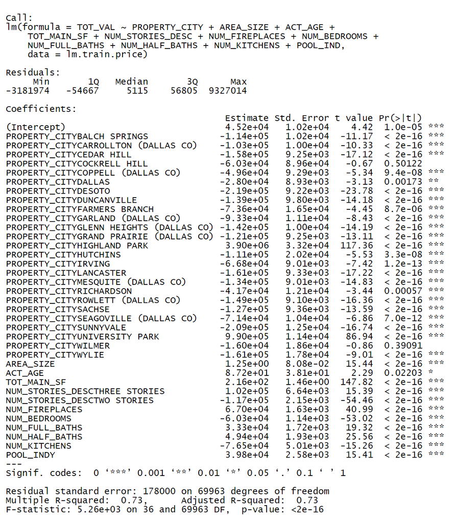